# R Notebook

```r
library(tidyverse)
library(lubridate)
library(tsibble)
library(tsibbledata)
library(fable)
```

## Question 1

Load in the nyc_bikes data from the tsibbledata package. Have an initial look at it to see what you’re working with. Create three new columns: one that stores only the year the bike was used, one that stores only the month the bike was used, and one that stores the date. Use the data stored in start_time to create these new columns.

```r
nyc_bikes <- nyc_bikes %>%
  mutate(month = month(start_time),
         year = year(start_time),
         date = date(start_time))

head(nyc_bikes)
```

| bike_id | start_time | stop_time | start_station | start_lat | start_long | end_station | end_lat | end_long | type | birth_year | gender | month | year | date |
| --- | --- | --- | --- | --- | --- | --- | --- | --- | --- | --- | --- | --- | --- | --- |
| 26301 | 2018-02-26 19:11:03 | 2018-02-26 19:15:40 | 3186 | 40.71959 | -74.04312 | 3203 | 40.72760 | -74.04425 | Subscriber | 1986 | Male | 2 | 2018 | 2018-02-26 |
| 26301 | 2018-02-27 07:52:49 | 2018-02-27 07:58:13 | 3203 | 40.72760 | -74.04425 | 3202 | 40.72722 | -74.03376 | Subscriber | 1979 | Male | 2 | 2018 | 2018-02-27 |
| 26301 | 2018-02-27 12:03:27 | 2018-02-27 12:04:54 | 3202 | 40.72722 | -74.03376 | 3638 | 40.72429 | -74.03548 | Subscriber | 1963 | Male | 2 | 2018 | 2018-02-27 |
| 26301 | 2018-02-27 13:53:51 | 2018-02-27 14:21:04 | 3638 | 40.72429 | -74.03548 | 3638 | 40.72429 | -74.03548 | Subscriber | 1984 | Male | 2 | 2018 | 2018-02-27 |
| 26301 | 2018-02-27 14:30:42 | 2018-02-27 14:33:11 | 3638 | 40.72429 | -74.03548 | 3187 | 40.72112 | -74.03805 | Subscriber | 1980 | Male | 2 | 2018 | 2018-02-27 |
| 26301 | 2018-02-27 16:31:04 | 2018-02-27 16:33:27 | 3187 | 40.72112 | -74.03805 | 3638 | 40.72429 | -74.03548 | Subscriber | 1980 | Male | 2 | 2018 | 2018-02-27 |

## Question 2

Summarise the number of bike hire counts by month. Make a plot of this data. *Hint: remember that to group time series (tsibble) data, you need to use index_by instead of group_by before your summarise function. What does this plot tell you about the time series? Do you think this downsampled data would be adequate to build a forecast with?

```r
bikes_month <- nyc_bikes %>%
  index_by(month) %>%
  summarise(bike_count = n())

bikes_month
```

| month | bike_count |
| --- | --- |
| 1 | 132 |
| 2 | 112 |
| 3 | 173 |
| 4 | 326 |
| 5 | 459 |
| 6 | 498 |
| 7 | 637 |
| 8 | 728 |
| 9 | 432 |
| 10 | 416 |

[output cut: 2 more lines]

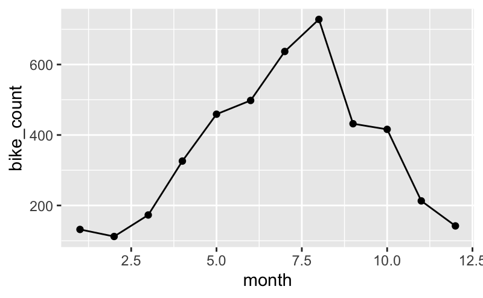

```r
bikes_month %>%
  ggplot() +
  aes(x = month, y = bike_count)+
  geom_line() +
  geom_point()
```

THere are definitely more bike rentals in the summer months suggesting that the time series is seasonal.

## Question 3

Now Summarise the number of bike hire counts by date. Make a plot of this new aggregated data. What does this plot tell you about the time series? Would this data be preferrable for time series forecasting compared to the monthly data?

```r
bikes_date <- nyc_bikes %>%
  index_by(date) %>%
  summarise(bike_count = n())
bikes_date
```

| date | bike_count |
| --- | --- |
| 2018-01-01 | 1 |
| 2018-01-02 | 3 |
| 2018-01-03 | 5 |
| 2018-01-04 | 1 |
| 2018-01-06 | 2 |
| 2018-01-07 | 1 |
| 2018-01-08 | 7 |
| 2018-01-09 | 6 |
| 2018-01-10 | 6 |
| 2018-01-11 | 10 |

[output cut: 337 more lines]

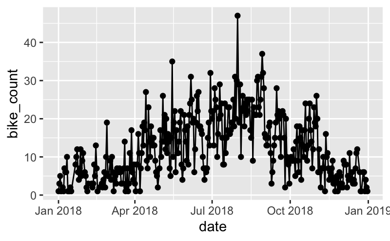

```r
bikes_date %>%
  ggplot()+
   aes(x = date, y = bike_count) +
  geom_line() +
  geom_point()
```

This would probably be of better use because it has more data points but clearly shows how each day is very verird

## Question 4

```r
bikes_date_gaps <- bikes_date %>%
  fill_gaps(bike_count = as.integer(median(bike_count)))


fit <- bikes_date_gaps %>%
  model(
    snaive = SNAIVE(bike_count),
    mean_model = MEAN(bike_count),
    arima = ARIMA(bike_count)
  )
fit
```

| snaive | mean_model | arima |
| --- | --- | --- |

```r
forecast_1 <- fit %>%
  fabletools::forecast(h = 120)
forecast_1
```

| .model | date | bike_count | .mean |
| --- | --- | --- | --- |
| snaive | 2019-01-01 |  | 10.000000 |
| snaive | 2019-01-02 |  | 6.000000 |
| snaive | 2019-01-03 |  | 6.000000 |
| snaive | 2019-01-04 |  | 1.000000 |
| snaive | 2019-01-05 |  | 4.000000 |
| snaive | 2019-01-06 |  | 2.000000 |
| snaive | 2019-01-07 |  | 1.000000 |
| snaive | 2019-01-08 |  | 10.000000 |
| snaive | 2019-01-09 |  | 6.000000 |
| snaive | 2019-01-10 |  | 6.000000 |

[output cut: 350 more lines]

## Question 5

Now we have our model fit, build a forecast to predict bike use over the next four months. Plot your models alongside your data. Hint: forecast parameter would be roughly 120 (30 days x 4 months)

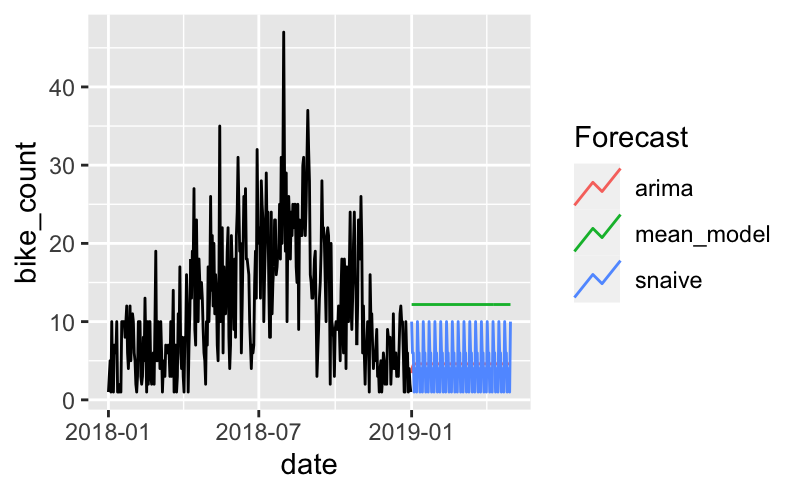

```r
forecast_1 %>%
  autoplot(bikes_date_gaps, level = NULL) +
  guides(colour = guide_legend(title = "Forecast"))
```

## Question 6

Test your model accuracy : choose a training data set from your main dataset, build a forecast on the training set, and then plot the training set forecast against the real data. Calculate model accuracy.

```r
train <- bikes_date_gaps %>%
  slice(n = 1:292)

test <- bikes_date_gaps %>%
  slice(n = 293:n())
```

```
Plot variable not specified, automatically selected `.vars = bike_count`
```

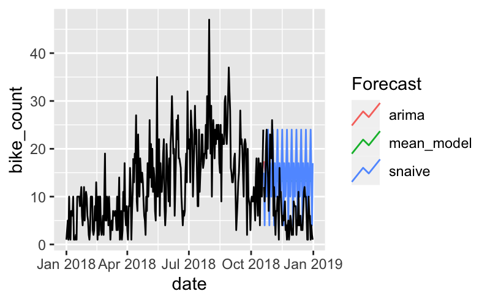

```r
fit <- train %>%
  model(
    snaive = SNAIVE(bike_count),
    mean_model = MEAN(bike_count),
    arima = ARIMA(bike_count)
  )

forecast_test <- fit %>%
  fabletools::forecast(h = 73)




forecast_test %>%
  autoplot(train, level = NULL) +
    autolayer(test, color = "black") +
    guides(colour=guide_legend(title="Forecast"))
```

```r
accuracy_model <- fabletools::accuracy(forecast_test, bikes_date_gaps)

accuracy_model %>%
  select(-.type) %>%
  arrange(RMSE)
```

| .model | ME | RMSE | MAE | MPE | MAPE | MASE | ACF1 |
| --- | --- | --- | --- | --- | --- | --- | --- |
| mean_model | -5.421233 | 7.962924 | 7.182727 | -240.2325 | 248.5585 | 1.062313 | 0.6562815 |
| arima | -6.395255 | 8.605040 | 7.886915 | -263.3429 | 270.2732 | 1.166461 | 0.6495131 |
| snaive | -6.342466 | 10.201397 | 8.424658 | -268.1643 | 281.4439 | 1.245992 | 0.3563438 |

## Question 7

Look at your forecast plots and accuracy values. Describe your results. Are your models a good fit for the data? If not, why not? What would you suggest doing with the data if you were expected to present these back to a client? For example, would you ask for more data? Would you test a different model?

The mean_model is the most accurate with the lowest RMSE but that is not saying much… I would say to the client that far more data needs to be collected over a larger period time because the time series is heavily affected by seasonal effects.

## Question 8

Make a simple ggplot (geom_point) which plots the start longitude and latitudes of each bike. Create a separate facet for each bike_id. Colour the dots in by month of use. What does this tell you about what month each bike was used most in?

Do the same for the end longitude and latitudes.

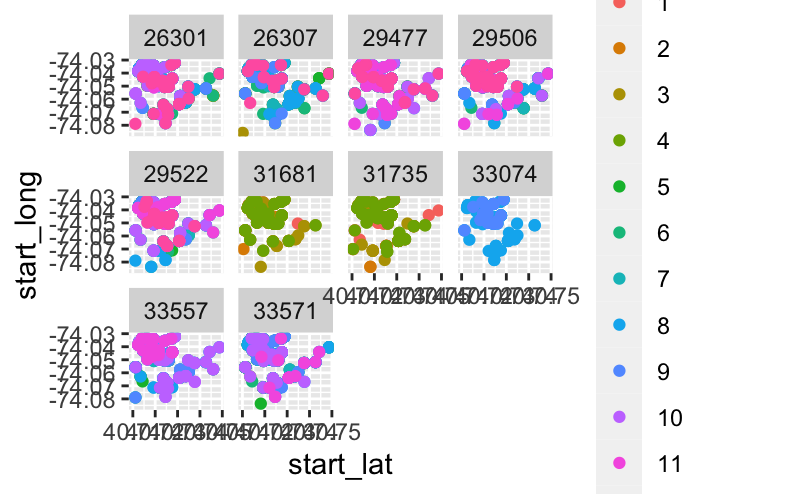

```r
nyc_bikes %>%
  ggplot() +
  aes(x = start_lat, y = start_long, colour = factor(month)) +
  geom_point() +
  facet_wrap(~bike_id)
```

```r
library(sf)
library(leaflet)
leaflet(nyc_bikes) %>%
 addTiles() %>%
  addMarkers(lng = ~start_long,
                   lat = ~start_lat,
                    clusterOptions = markerClusterOptions())
```

[interactive chart not shown]

```r
NA
NA
```